*Note: These are some sketchy personal notes from the ADDING 2022 conference at UGA.*

# ADDING 2022

Conference Notes

D. Zack Garza

University of Georgia  
[email protected]

Last updated: 2022-05-01

# 1 Talk 1: Jordan Ellenberg, Sparsity of rational points on moduli spaces

[ADDING Conference](https://mathmeetings.net/conferences/view/1181)

> [Reference for this talk](https://arxiv.org/abs/2109.01043)

How many homogeneous forms in ${\mathbb{Z}}[x_0,\cdots, x_n]$ are there with discriminant equal to 1? More accurately, there is a $\operatorname{PGL}{\hbox{-}}$action, so how many $\operatorname{PGL}$ orbits are there? More generally: how many are there with discriminant divisible only by primes in some finite set $S$?

There are finitely many.

The general philosophy is that there should be only finitely many classes of $X$ with good reduction outside of $S$ – this is known e.g. for abelian varieties of dimension $g$, see Faltings’ proof of Mordell.

In terms of rational points, there is a trichotomy:

- $g=0$,
- $g=1$,
- $g > 1$.

This in fact breaks into a dichotomy:

- $g\leq 1$,
- $g > 1$.

There are bounds on rational point counts on $X$ with height at most $B$:

- $g=0 \leadsto \ll_X B^2$
- $g=1\leadsto \ll_X \log B$ (Mordell)
- $g\geq 2\leadsto \ll_X C_X$ where $C$ is a constant depending on $X$ (Faltings)

Here we’ll dichotomize this in a different way: $g=0$ and $g > 0$. We say $X$ has **sparse points** if ${\sharp}X({\mathbb{Q}}) \ll B^{\varepsilon}$.

Let $K\in \mathsf{Field}_{/ {{\mathbb{Q}}}} , S\in {\operatorname{Places}}(K)$ finite, $U_K \hookrightarrow{\mathbb{P}}^N$ a quasiprojective variety with a geometric variation of Hodge structure with finite-to-one period map, making $U_X$ an interesting moduli space of something. Then the periods of $U({\mathcal{O}}_K{ \left[ { \scriptstyle \frac{1}{S} } \right] })$ are sparse.

The anabelian part: $U$ has large $\pi_1$, so lots of etale covers. E.g. if $U$ is a moduli of hypersurfaces, take the universal curve ${\mathcal{H}}\to U$, then $H^n({\mathcal{H}}_t; C_m)$ varies and this can be interpreted as a moduli space with level structure. We try to show that large $\pi_1$ implies sparseness. This isn’t quite true, since e.g. blowing up introduces lots of rational points, so a stronger condition is needed: $\pi_1(U)$ is infinite and for every finite-dimensional $V \subseteq U$, $\pi_1(V)\to \pi_1(U)$ has infinite image.

Why is it useful to have lots of etale covers? Consider $x-y=1$ for $x,y\in {\mathbb{Z}}{ \left[ { \scriptstyle \frac{1}{S} } \right] }^{\times}$ and $S = \left\{{2,3}\right\}$. The $S{\hbox{-}}$units theorem of Siegel guarantees there are only finitely many solutions. One way to approach this: if $x=2^a3^b$, we know $x$ up to squares: $x=s,2s,3s,6s$ for $s$ a square, as is $y$. This yields a system
$$\begin{align*}
m^2-n^2 &=1 \\
m^2-2n^2 &= 1 \\
2m^2-n^2 &= 1 \\
\vdots & \qquad
,\end{align*}
which e.g. some can be solved using techniques for Pell equations. Having higher degree rigidifies the situation, so perhaps there are more techniques to solve them. Strategy: trade one hard equation for a finite list of higher degree easier equations.$$

A partitioning trick for integral points: $Y\to U$ is a finite etale cover, then there are a finite number of twists $\left\{{Y_1,\cdots, Y_m}\right\}$ (all isomorphic over ${ \mkern 1.5mu\overline{\mkern-1.5mu \mathbb{Q} \mkern-1.5mu}\mkern 1.5mu }$) with $Y_i\to U$ such that every point in $U({\mathbb{Z}}{ \left[ { \scriptstyle \frac{1}{S} } \right] })$is in the image of $Y({\mathbb{Z}}{ \left[ { \scriptstyle \frac{1}{S} } \right] })$ for some $i$. So
$$\begin{align*}
{\textstyle\coprod}_i Y_i({\mathbb{Z}}{ \left[ { \scriptstyle \frac{1}{S} } \right] }) \rightrightarrows U({\mathbb{Z}}{ \left[ { \scriptstyle \frac{1}{S} } \right] })
.\end{align*}$$

> Note: missed the exponent on $B$, need to fix.

Useful to control numbers of points for curves you know nothing about. Walsh removes the ${\varepsilon}$ in all terms, Selberg, Brolog generalized to higher dimensions, CCDN make the constant effective. Pitch: these theorems are useful for other theorems which are not ostensibly about uniformity!

All we can control in this situation is the degree of $Y_i\to U$ and $U\subseteq {\mathbb{P}}^N$ has a degree, so we can control the degree of the $Y_i$. Broberg gives a bound $\ll B^{n+1\over d^{1\over n}}$ where $n=\dim U$. It doesn’t actually matter what this is, just that it decreases in $d$, and we can take higher degree covers.

“Anabelian”: $\pi_1$ somehow tells the entire story.

Heath-Brown’s technique uses $p{\hbox{-}}$adic repulsion of points for $X({\mathbb{Q}})\to X({ {\mathbb{Q}}_p })$ where low-height points do not end up nearby. Recall that there is a SES
$$\begin{align*}
1\to \pi_1^\text{ét}(X_{{ \mkern 1.5mu\overline{\mkern-1.5mu \mathbb{Q} \mkern-1.5mu}\mkern 1.5mu }}) \to \pi_1^\text{ét}(X_{\mathbb{Q}}) \to G_{\mathbb{Q}}\to 1
,\end{align*}
and any point \(p\in X({\mathbb{Q}})\) gives a section, thought of as \(X({\mathbb{Q}}) \to H^1(G_{\mathbb{Q}}; \pi_1^\text{ét}(X_{{ \mkern 1.5mu\overline{\mkern-1.5mu \mathbb{Q} \mkern-1.5mu}\mkern 1.5mu }}))\). Anabelian-ness: embed into some large interesting geometric space like this.$$

This cohomology group has a topology where $p, q\in X({\mathbb{Q}})$ are nearby iff there exists a higher degree etale cover $Y\to X$ (small subsets correspond to large index subgroups in the profinite topology) such that $p, q$ both lift to $Y({\mathbb{Q}})$.

How this goes for curves: $C({\mathbb{Q}}) \to \operatorname{Jac}({\mathbb{Q}})$, and one can tensor up to $\operatorname{Jac}({\mathbb{Q}}) \otimes_{{\mathbb{Z}}} { {\mathbb{Z}}_{\widehat{p}} }$. Modern take: points are close if they differ by a power of $p$ in the Mordell-Weil group. Interpretation of the main theorem: Heath-Brown in more general profinite topologies.

# 2 Talk 2: Wanlin Li, Ceresa cycle and hyperellipticity

A hyperbolic curve is determined by its $\pi_1^\text{ét}$.

Recall $y^2=f(x)$ defines a hyperelliptic curve $C$, which admits an involution $(x,y)\to(x,-y)$ and produces a degree 2 map
$$\begin{align*}
C &\to {\mathbb{P}}^1 \\
(x,y) &\mapsto x
.\end{align*}$$

Let ${ \mkern 1.5mu\overline{\mkern-1.5muk\mkern-1.5mu}\mkern 1.5mu }$ be a separable closure of $k$. There is a fibration induced by taking a geometric point of $\operatorname{Spec}k$ and pulling back:

[figure not shown]

> [Link to Diagram](https://q.uiver.app/?q=WzAsNCxbMCwwLCJDX3tcXGtiYXJ9Il0sWzIsMCwiQyJdLFsyLDIsIlxcc3BlYyBrIl0sWzAsMiwiXFxzcGVjIFxca2JhciJdLFszLDJdLFsxLDJdLFswLDFdLFswLDNdLFswLDIsIiIsMSx7InN0eWxlIjp7Im5hbWUiOiJjb3JuZXIifX1dXQ==)

As in topology, this induces a LES in homotopy, which here splits into SESs. In particular,
$$\begin{align*}
1\to \pi_1(C_{ { \mkern 1.5mu\overline{\mkern-1.5muk\mkern-1.5mu}\mkern 1.5mu } })\to \pi_1(C_k) \to { \mathsf{Gal}} ( { \mkern 1.5mu\overline{\mkern-1.5muk\mkern-1.5mu}\mkern 1.5mu } /k)
.\end{align*}
A point induces a section and thus a map \({ \mathsf{Gal}} ( { \mkern 1.5mu\overline{\mkern-1.5muk\mkern-1.5mu}\mkern 1.5mu } /k) \to \mathop{\mathrm{Aut}}\pi_1(C_{ { \mkern 1.5mu\overline{\mkern-1.5muk\mkern-1.5mu}\mkern 1.5mu } })\). Take the lower central series of \(\pi \mathrel{\vcenter{:}}=\pi_1(C_{ { \mkern 1.5mu\overline{\mkern-1.5muk\mkern-1.5mu}\mkern 1.5mu } })\), this induces
\begin{align*}
1\to L^2\pi/L^3\pi \to \pi/L^3\pi \to \pi/L^1 \pi = \pi^{\operatorname{ab}}\to 1
\end{align*}
where the first term is abelian.$$

> See Davis-Pries-Wickelgren for applications to Fermat curves.

This extension corresponds to an element in $\mu(C) \in H^1(G_{ { \mkern 1.5mu\overline{\mkern-1.5muk\mkern-1.5mu}\mkern 1.5mu } }; \mathop{\mathrm{Hom}}(\pi^{\operatorname{ab}}, L^2\pi/L^3\pi ) )$, and when $C$ is hyperelliptic $\mu(C) = 0$. Does the converse hold?

There exist non-hyperelliptic curves $C$ over $k$ such that $\mu(C)$ is torsion – in particular, the *Fricke-Macbeath* curve, which is genus 7 Hurwitz. Moreover if $C_1\to C_2$ then $\mu(C_1)$ torsion implies $\mu(C_2)$ torsion.

> See https://arxiv.org/abs/2004.06146?

$\mu(C)$ is the $\ell{\hbox{-}}$adic cycles class associated to the **Ceresa cycle**.

> See [Hain-Matsumoto](https://arxiv.org/abs/math/0306037) and [Pulte](https://projecteuclid.org/journals/duke-mathematical-journal/volume-57/issue-3/The-fundamental-group-of-a-Riemann-surface--Mixed-Hodge/10.1215/S0012-7094-88-05732-8.short)

For $C_{/ {k}}$ and $p\in C(K)$, the Abel-Jacobi map yields \begin{align*} \operatorname{AJ}: C &\hookrightarrow\operatorname{Jac}(C) \\ q &\mapsto [q-p] .\end{align*} So define the **Ceresa cycle** as \begin{align*} \tilde c \mathrel{\vcenter{:}}=\operatorname{AJ}(C) - \mkern 1.5mu\overline{\mkern-1.5mu \operatorname{AJ}(C) \mkern-1.5mu}\mkern 1.5mu \mathrel{\vcenter{:}}=[q-p] - [p-q] .\end{align*} Note that $\tilde c$ is homologically trivial in Chow, but algebraically *nontrivial* for a very general $C_{/ {{\mathbb{C}}}}$ with $g\geq 3$.

There is an explicit non-hyperelliptic curve $C$ with $\tilde c$ torsion:
$$\begin{align*}
x^4 + xz^3 + y^3z = 0 \subseteq {\mathbb{P}}^2, \qquad p = {\left[ {0,0,1} \right]}
.\end{align*}$$

> See https://arxiv.org/abs/2105.07160?

Consider curves over the local field $K = {\mathbb{C}}{\left[\left[ t \right]\right] }$. Note ${ \mathsf{Gal}} (\mkern 1.5mu\overline{\mkern-1.5mu{\mathbb{C}}{\left[\left[ t \right]\right] }\mkern-1.5mu}\mkern 1.5mu/{\mathbb{C}}{\left[\left[ t \right]\right] }) = \widehat{{\mathbb{Z}}}$, so this resembles a circle, and one can degenerate a family over the punctured disc. Apply nonabelian Picard-Lefschetz due to Asada-Matsumoto-Oda: if $C$ has semistable reduction then the monodromy of $C/{\mathbb{C}}{\left[\left[ t \right]\right] }$ is given by a multi-twist, i.e. a product of Dehn twists about simple closed curves. One can explicitly compute the Ceresa class in this situation. The degeneration data can be encoded as a tropical curve (essentially the dual graph of the special fiber).

> See Asada-Matsumoto-Oda

$\mu(C)$ is always torsion for $C$ defined over ${\mathbb{C}}{\left[\left[ t \right]\right] }$.

There is a notion of “hyperelliptic” for tropical curves: quotienting by the involution yields a tree.

# 3 Misc Notes

See Iwasawa group.

Section conjecture: $\mathop{\mathrm{Sec}}(Y/K) \cong Y(K)$, i.e. every section comes from a rational point.

See the recent Lawrence-Venkatesh proof of Mordell. See *Selmer section set* and *adelic sections*.

Hyperbolic curves:

- $g=0 \leadsto {\mathbb{P}}^1\setminus Z$ where ${\sharp}Z \geq 3$
- $g=1 \leadsto$ affine
- $g\geq 2$: anything.

For $X_{/ {K}}$ for $K\in \mathsf{Field}_{/ {{\mathbb{Q}}}}$ smooth hyperbolic with good reduction away from $S$, ${\sharp}X({\mathcal{O}}_{K, S}) < \infty$ by Faltings. See Bloch-Kato and Fontaine-Mazur conjectures.

# 4 Sunday, May 01

I missed the first two talks 😦

# 5 Kiran Kedlaya: Crystalline companions as an anabelian phenomenon

Setup: $k = {\mathbb{F}}_q, q=p^n, X\in {\mathsf{Sch}}_{/ {k}}$ smooth geometrically connected, $\ell\neq p$ arbitrary. Recall
$$\begin{align*}
1\to \pi_1 X_{ { \mkern 1.5mu\overline{\mkern-1.5muk\mkern-1.5mu}\mkern 1.5mu } } \to \pi_1 X \to G_k = { \widehat{ \mathbb{Z} } }\to 1
.\end{align*}
Anabelian philosophy: everything you’d want to know about \(X\) is contained in \(\pi_1 X\).$$

If $X$ is an affine curve, then $\pi_1^{{\mathrm{tame}}} X$ determines $X$.

Problem: if $X$ is an affine genus $g$ curve with $m$ punctures, $\pi_1^{{\scriptscriptstyle \mathrm{prime-to-}p}} X_{ { \mkern 1.5mu\overline{\mkern-1.5muk\mkern-1.5mu}\mkern 1.5mu } }$ is the prime-to-$p$ completion of $\mathsf{Free}(2g+m-1)$, independently of $X$. Since sections induce $G_k\to \mathop{\mathrm{Out}}(\pi_1 X_{ { \mkern 1.5mu\overline{\mkern-1.5muk\mkern-1.5mu}\mkern 1.5mu } })$, we have lots of tame continuous $\mkern 1.5mu\overline{\mkern-1.5mu{ {\mathbb{Q}}_\ell }\mkern-1.5mu}\mkern 1.5mu$ reps of $\pi_1 X_{ { \mkern 1.5mu\overline{\mkern-1.5muk\mkern-1.5mu}\mkern 1.5mu } }$, but very few are fixed by Frobenius.

Such representations only have “geometric origins,” i.e. if ${\mathcal{E}}$ is a lisse ${ {\mathbb{Q}}_\ell }{\hbox{-}}$sheaf, i.e. a lisse $F{\hbox{-}}$sheaf with $[F:{ {\mathbb{Q}}_\ell }] < \infty$, which is irreducible with determinant of finite order, then it appears on relative etale cohomology of $\pi:Y\to X$ for some $Y$.

This is known in $\dim X = 1$, due to Deligne, around the same time Drinfeld proved Langlands for $\operatorname{GL}_2(k(X))$ for $k(X)$ a function field (or really the adeles). So all arithmetic reps of $\pi_1$ *come from geometry*.

Note that $Y$ will eventually not even be a scheme. The determinant condition rules out transcendental twists. Galois side: lisse sheaves on $X$; automorphic side: reps values in $\operatorname{GL}_n({\mathbb{A}}_K)$ for $K$ a field. The proof above involves exhibiting the Galois objects as coming from relative etale cohomology in moduli of shtukas. A priori one only knows Frobenius traces, but this turns out to be enough to uniquely characterize things in this situation.

Later Lafforgue did this for $\operatorname{GL}_n$, but the corresponding statement about arithmetic reps is wide open.

If ${\mathcal{E}}$ as above, the Frobenius traces at all closed points $x\in {\left\lvert {X} \right\rvert}$ are algebraic over ${\mathbb{Q}}$.

Fix an algebraic closure ${ \mkern 1.5mu\overline{\mkern-1.5mu \mathbb{Q} \mkern-1.5mu}\mkern 1.5mu }$ and two primes $\ell, \ell'\neq p$ and fix embeddings ${ \mkern 1.5mu\overline{\mkern-1.5mu \mathbb{Q} \mkern-1.5mu}\mkern 1.5mu }\hookrightarrow{ \mkern 1.5mu\overline{\mkern-1.5mu \mathbb{Q} \mkern-1.5mu}\mkern 1.5mu }_\ell$ and ${ \mkern 1.5mu\overline{\mkern-1.5mu \mathbb{Q} \mkern-1.5mu}\mkern 1.5mu }\hookrightarrow{ \mkern 1.5mu\overline{\mkern-1.5mu \mathbb{Q} \mkern-1.5mu}\mkern 1.5mu }_{\ell'}$. Let ${\mathcal{E}},{\mathcal{E}}'$ be lisse ${ \mkern 1.5mu\overline{\mkern-1.5mu \mathbb{Q} \mkern-1.5mu}\mkern 1.5mu }_\ell, { \mkern 1.5mu\overline{\mkern-1.5mu \mathbb{Q} \mkern-1.5mu}\mkern 1.5mu }_{\ell'}$ sheaves (resp.) on $X$. Say ${\mathcal{E}},{\mathcal{E}}'$ are **companions** iff for every $x\in{\left\lvert {X} \right\rvert}$ the Frobenius traces at $x$ are equal in ${ \mkern 1.5mu\overline{\mkern-1.5mu \mathbb{Q} \mkern-1.5mu}\mkern 1.5mu }$.

Note that ${\mathcal{E}}$ determines ${\mathcal{E}}'$ up to semisimplification, using $L{\hbox{-}}$function techniques. Moreover properties like being irreducible or having finite determinant hold simultaneously for them.

With this setup, a lisse ${ \mkern 1.5mu\overline{\mkern-1.5mu \mathbb{Q} \mkern-1.5mu}\mkern 1.5mu }_{\ell}$ sheaf ${\mathcal{E}}_\ell$ admits a compantion ${\mathcal{E}}'$ which is a ${ \mkern 1.5mu\overline{\mkern-1.5mu \mathbb{Q} \mkern-1.5mu}\mkern 1.5mu }_{\ell'}$ for chosen embeddings of ${\mathbb{Q}}$ for which all traces are in ${ \mkern 1.5mu\overline{\mkern-1.5mu \mathbb{Q} \mkern-1.5mu}\mkern 1.5mu }$, i.e. irreducible and finite determinant. This is true in arbitrary dimension.

What about when $\ell=p$? There are somehow too many and too few lisse ${ \mkern 1.5mu\overline{\mkern-1.5mu \mathbb{Q} \mkern-1.5mu}\mkern 1.5mu }_p$ sheaves! E.g. the Lefschetz trace formula doesn’t hold. Instead use the Riemann-Hilbert correspondence – the $p{\hbox{-}}$adic analogues of lisse sheaves are certain $p{\hbox{-}}$adic integrable connections. How to construct: start with $X$ affine and glue. Choose a smooth affine formal scheme over $W(k)$ with special fiber $P_k \cong X$. Let $K = \operatorname{ff}W(k)$ and $P_K$ be the Raynaud generic fiber. See Tate model, Berkovich model, etc for rigid analytic geometry. Let ${\mathbb{A}}_K^n \leadsto \widehat{{\mathbb{A}}^n}_{W(k)}$, a closed unit disc over $K$.

Some definitions:

- A **convergent isocrystal** is a vector bundle with an integrable connection on $P_K$.
- A **convergent $F{\hbox{-}}$isocrystal** is this and a compatible action of (a lift of) Frobenius.
- An **overconvergent $F{\hbox{-}}$isocrystal** is this on some structural enlargment of $P_K$ which takes the closed unit disc to the disc of radius $1+{\varepsilon}$.

These are similar to $\pi_1(X_{ { \mkern 1.5mu\overline{\mkern-1.5muk\mkern-1.5mu}\mkern 1.5mu } }){\hbox{-}}$representations. Issue: $p{\hbox{-}}$adic antidifferentiation is hard; the integral of a formal power series converging on the closed disc only converges on the open disc.

If $X$ is smooth this recovers Berthelot’s rigid cohomology, which is a refinement of crystalline cohomology if $X$ is proper. This yields a 6 functor formalism, and has the same moving parts as etale cohomology.

The Langlands correspondence extends to these when $\dim X = 1$.

The content here: Lafforgue’s original proof can now be run with $p{\hbox{-}}$adic coefficients instead of just $\ell{\hbox{-}}$adic coefficients.

The companion theorem extends to both $\ell=p$ and $\ell'=p$.

Deligne posited the existence of a *petit camarade crystalline*, a little crystalline friend. ❇🙂

## 5.1 Applications

A partial result toward a conjecture of Simpson. Let $X_{/ {{\mathbb{C}}}}$ be a smooth cohomologically rigid local system (so no nontrivial deformations) which is irreducible with finite determinant. Are these of geometric origin? In particular, is there a ${ {\mathbb{Z}}\mathrm{VHS} }$? Esnault-Groecherig show that the monodromy representation factors through $\operatorname{GL}_n({\mathcal{O}}_K) \to \operatorname{GL}_n({\mathbb{C}})$ for some $K\in \mathsf{Field}_{/ {{\mathbb{Q}}}}$.

Idea: start from complex geometry, go to $p{\hbox{-}}$adic geometry, yields an overconvergent $F{\hbox{-}}$crystal. This yields integrality at $p$; use companions to go back to a lisse $\ell{\hbox{-}}$adic sheaf, then back to ${\mathbb{C}}$ to get integrality at $\ell$.

Going the other way, $\ell\to p$: one can prove “of geometric origin” results when $\operatorname{rank}{\mathcal{E}}= 2$ (Krishnmorthy-Pal). Idea: go from $\ell\to p$, make a candidate for the crystalline Dieudonne module for some family of AVs. One will have a bound on the motivic weight, which is at most $\operatorname{rank}{\mathcal{E}}- 1$.

A word on the proof: define a moduli stack $M_n$ of mod $p^n$ $F{\hbox{-}}$crystals, which is a horrendous algebraic stack. These are roughly coherent sheaves with extra data. Study some finite-type pieces using slops, and is universally closed since one can take flat limits along curves. Take the Zariski closure of companion points, then take stable images to get some $M_n''$.

Show that every point in each component of it is a companion point using horizontal companions (as opposed to vertical in the fiber direction). Then show each component maps isomorphically to $S$, which is a pointwise condition on $S$. This only uses the companion on the fiber, which is easier to study.

# 6 Alex Smith: Simple abelian varieties over finite fields with extreme point counts

Given $n > 0$, there is an $A\in {\mathsf{Ab}}{\mathsf{Var}}_{/ {{\mathbb{F}}_2}}$ with ${\sharp}A({\mathbb{F}}_2) = n$.

Recall the Weil bounds: given $A_{/ {{\mathbb{F}}_q}}$,
$$\begin{align*}
(q-2q^{1\over 2} + 1)^g \leq {\sharp}A({\mathbb{F}}_q) \leq (q+2q^{1\over 2} +1)^g
.\end{align*}$$

Let $\left\{{\alpha_i}\right\}_{1\leq i\leq 2g}$ be the eigenvalues of $\operatorname{Frob}\curvearrowright H_{\text{ét}}^1(A { \underset{\scriptscriptstyle {{\mathbb{F}}_q} }{\times} } \mkern 1.5mu\overline{\mkern-1.5mu{\mathbb{F}}_q\mkern-1.5mu}\mkern 1.5mu; { {\mathbb{Z}}_\ell })$. Recall the Weil conjectures:

- All embeddings ${\mathbb{Q}}( \alpha_i) \hookrightarrow{\mathbb{C}}$ satisfy ${\left\lvert { \alpha_i} \right\rvert} = q^{1\over 2}$.
- Lefschetz trace: ${\sharp}A({\mathbb{F}}_q) = \prod_{1\leq i\leq 2g}( \alpha_i - 1) = \prod(q+1 - \alpha_i - \mkern 1.5mu\overline{\mkern-1.5mu \alpha_i\mkern-1.5mu}\mkern 1.5mu )^{1\over 2}$ Note that these real numbers sit in $[-2q^{1\over 2}, 2q^{1\over 2}] \subseteq {\mathbb{R}}$.

Given $\Sigma \subseteq {\mathbb{C}}$ we say $\alpha$ is **totally $\Sigma$** iff all conjugates of $\alpha$ are contained in $\Sigma$.

Remarkably for AVs, the $\alpha_i$ tell the entire story! Honda-Tate theory gives a correspondence
$$\begin{align*}
\left\{{\substack{
\text{Abelian varieties over ${\mathbb{F}}_q$}
}}\right\}/\sim_{\scriptscriptstyle \text{isogeny}}
&\rightleftharpoons
\left\{{\substack{
\text{Totally $I_q$ algebraic integers}
}}\right\}/\sim_{\scriptscriptstyle\text{conjgacy}}
\end{align*}
where \(I = [-2\sqrt q, 2\sqrt q]\). Tate showed injectivity, Honda used CM theory to show surjectivity.$$

Given any $q$ and any $n \gg_q 0$, there is an $A\in{\mathsf{Ab}}{\mathsf{Var}}_{/ {{\mathbb{F}}_q}}$ with ${\sharp}A({\mathbb{F}}_q) = n$.

Idea: Howe-Kedlaya works infinitely often. One can’t attain *every* integer in the Weil bound interval, but you can get pretty close:

Given $g \gg_q 0$ and
$$\begin{align*}
n\in [(q-2\sqrt q + 3)^g, (q+2\sqrt q - 1 - q^{-1})^g]
,\end{align*}
there exists \(A\) with \({\sharp}A({\mathbb{F}}_q) = n\).$$

Given $\alpha\in {\mathbb{R}}$ and ${\varepsilon}$, one can produce totally $I$ algebraic integers for $I = [ \alpha, 4+ \alpha+{\varepsilon}]$ fitting the arcsin distribution:

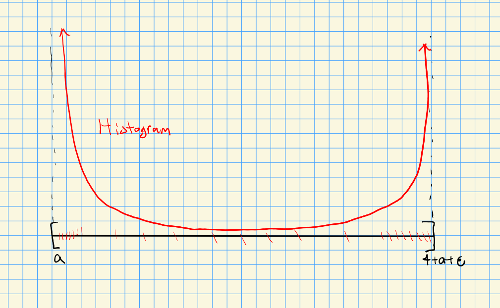

For ${\varepsilon}= \alpha = 0$, choose a large cyclotomic polynomial, whose roots are roughly equidistributed in $S^1$, then map to $[-2, 2]$. Solving this for non-rational $\alpha$ and ${\varepsilon}=0$ is a big open problem.

## 6.1 Schur-Segal-Smyth trace problem

Find the minimal $t$ such that for any ${\varepsilon}> 0$, infinitely many totally positive algebraic integers satisfy
$$\begin{align*}
\operatorname{tr}(\alpha)/\deg(\alpha) < t + {\varepsilon}
.\end{align*}$$

$t\geq 1$.

Take a totally positive algebraic integer with conjugates $\left\{{\alpha_i}\right\}_{i\leq n}$ with minimal polynomial $p$. Now apply AMGM:
$$\begin{align*}
1\leq {\left\lvert {p(0)} \right\rvert} = \qty{\prod a_i}^{n\over n}\leq_{{\mathrm{AMGM}}}\qty{\sum a_i \over n}^n
.\end{align*}$$

Smyth shows that $t = \operatorname{tr}(\alpha)/\deg( \alpha)\geq 1.771$ with 14 exceptions; Wang-Wu-Wu shows $t\geq 1.793$. Serre showed this argument can never show $t\geq 1.899$, Alex showed it can not show $t\geq 1.81$, so we’re approaching the limit of Smyth’s method.

Smyth’s method limits to the right answer, and thus $t\leq 1.81$. In particular, $t\neq 2$.

Consequence: there are things that work better than the arcsin distribution.

Given sufficiently large square $q$, there are infinitely many $A_{/ {{\mathbb{F}}_q}}$ with
$$\begin{align*}
{\sharp}A({\mathbb{F}}_q) \geq (q + 2\sqrt q - 0.81)^{\dim A}
,\end{align*}
but only finitely many with
\begin{align*}
{\sharp}A({\mathbb{F}}_q) \geq (q+2\sqrt q - 0.8)^{\dim A}
.\end{align*}$$

Given algebraic integers $\alpha$ with conjugates $\left\{{\alpha_i}\right\}_{i\leq n}$, let
$$\begin{align*}
\mu_{\alpha}= {1\over n}\sum \delta_{ \alpha_i}
.\end{align*}$$

There is a weak-$*$ topology on the space of such measures.

Choose $\Sigma \subseteq {\mathbb{R}}$ with countably many components (e.g. excluding Cantor sets) of *capacity* $c > 1$. TFAE are equivalent for a probability measure $\mu$ on $\Sigma$:

- There are totally $\Sigma$ algebraic integers $\alpha_i$ whose distributions $\mu_{\alpha_i}$ as above conver to $\mu$.
- For any integer polynomial $Q\neq 0$,
  $$\begin{align*}
  \int_{\Sigma} \log{\left\lvert {Q} \right\rvert} \,d\mu\geq 0
  .\end{align*}$$

Idea of proof: apply Minkowski’s 2nd theorem as a source of promising polynomials. Use an optimized distribution that avoids the 14 exceptions, whose average traces beat the previous averages:

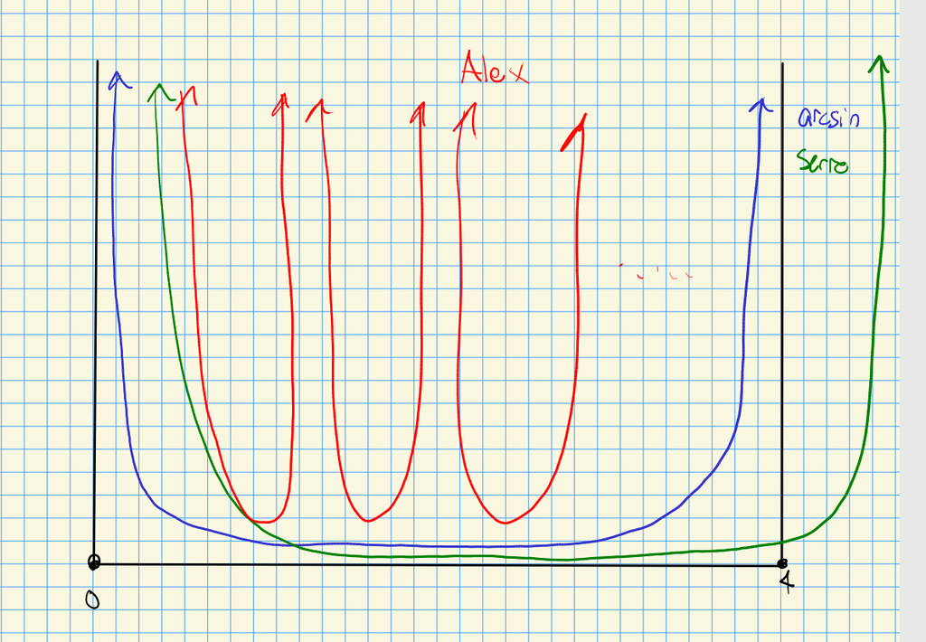

# 7 Bibliography